# Explore and summarize data (Red wine) by Maha Hassan

### 1.2 Fixed acidity

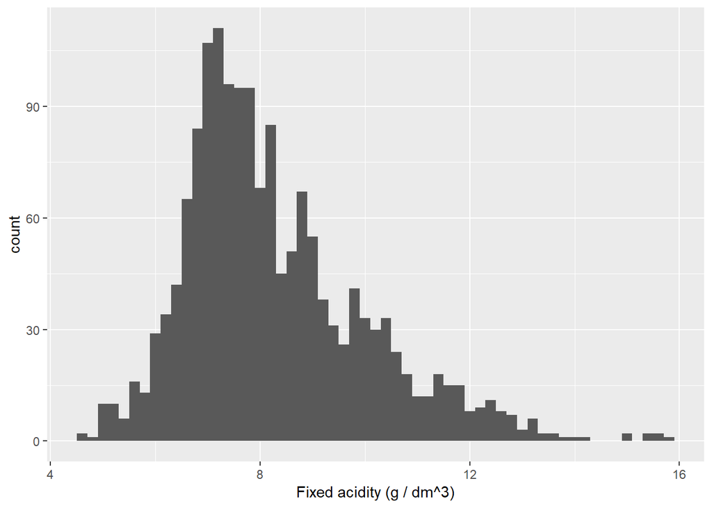

The fixed acidity values range between 4 and 16 and the plot is right skewed. we will use scale x log10 to make it more normally distributed.

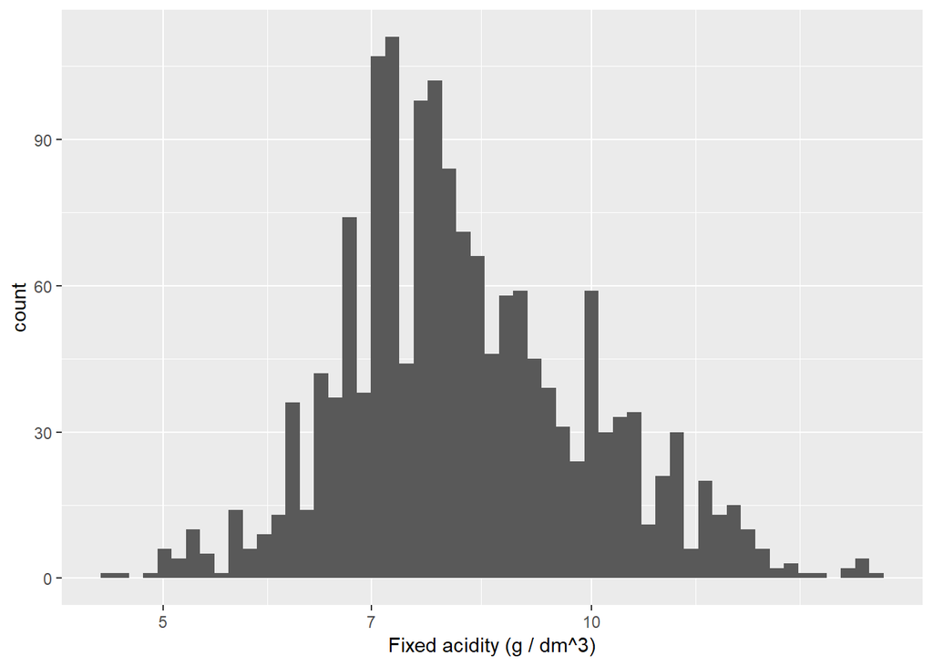

Now we see it has become more normal.

### 1.3 Volatile acidity

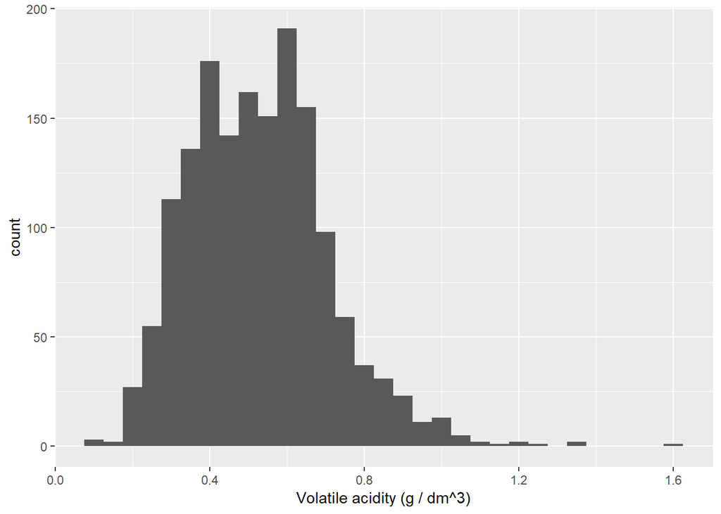

The data is skewed to the right and most of them vary between0 and 1.1, will try the scale x log10 again and see it becomes normally distributed.

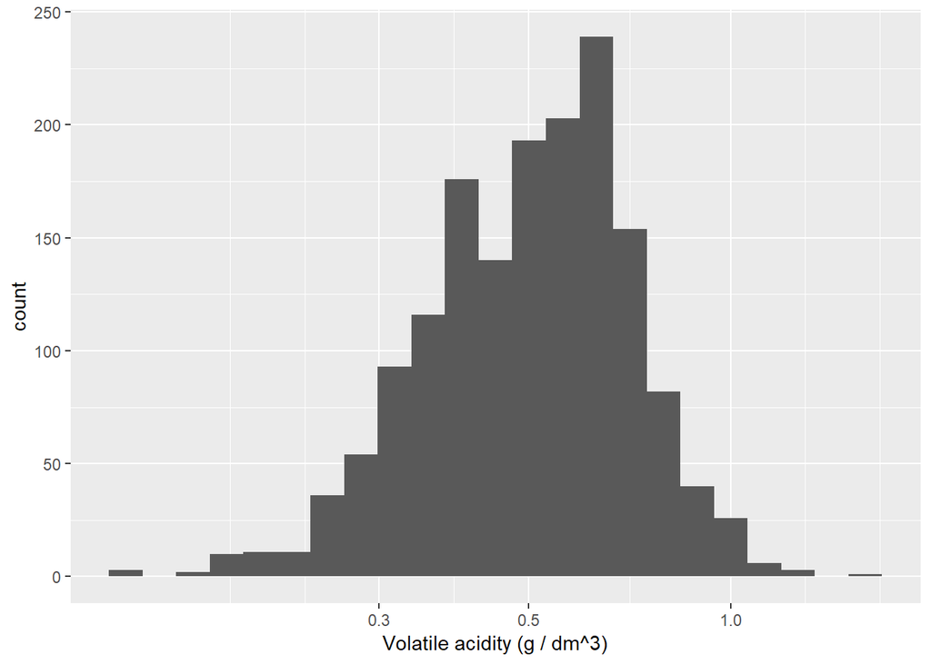

### 1.4 Citric acidity

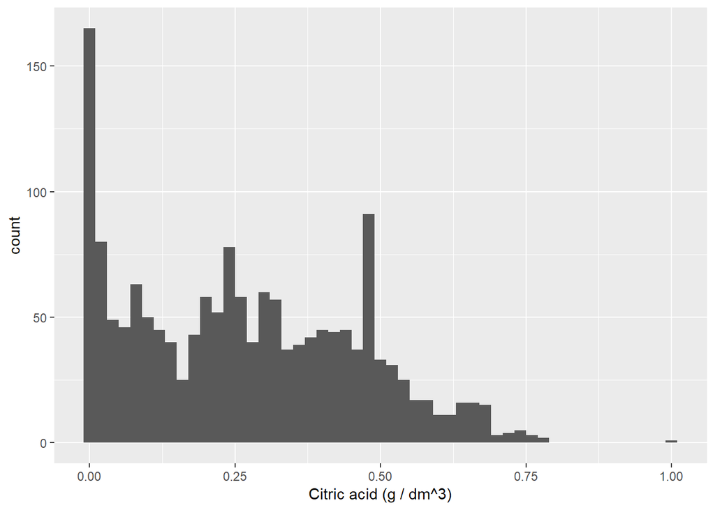

Citric acid ranges between 0 and 0.75 and ther is good number of wine samples that has 0 percent of citric acid. let’s see how many

```
## [1] 132  13
```

As seen, there are 132 types of wine in the data set that has no citric acid.

### 1.5 Residual sugar

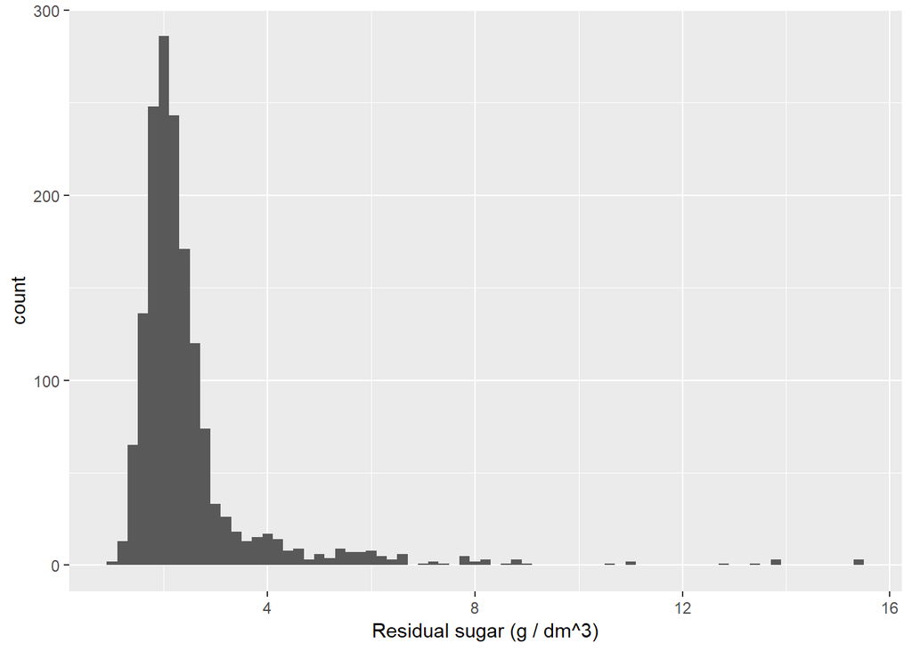

Now we limit the x axis to (0 to 5)

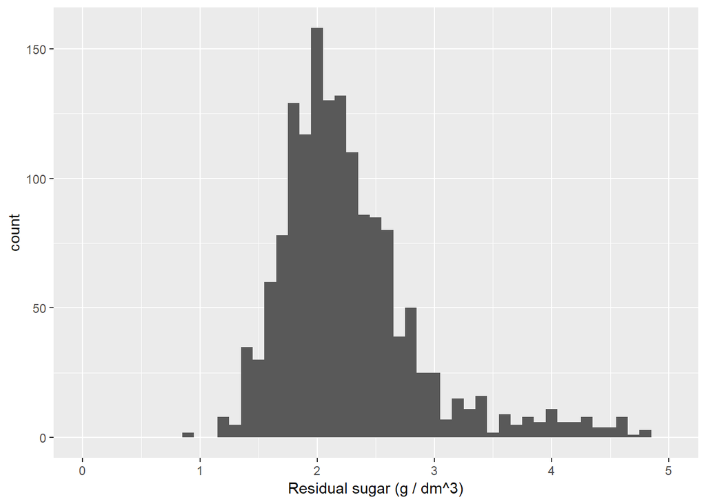

The highest residual sugar value is between 1.5 and 2.5, there are outliers that made data skewed to the right in the first plot but then when I limited the data range to 5 the data became normally distributed.

### 1.6 Chlorides

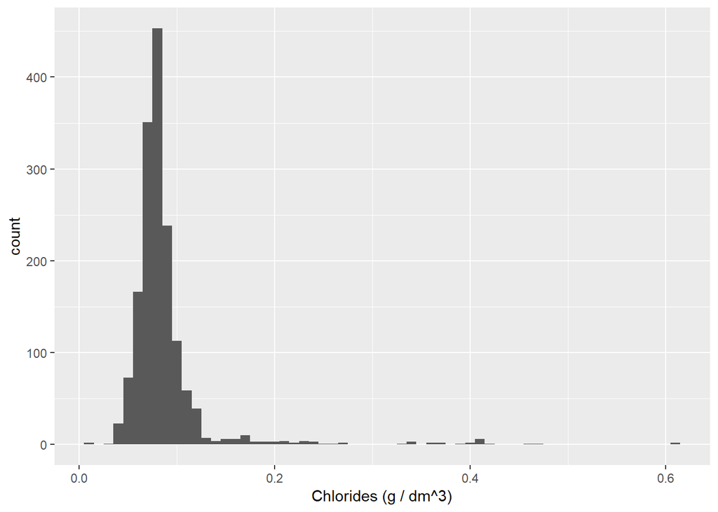

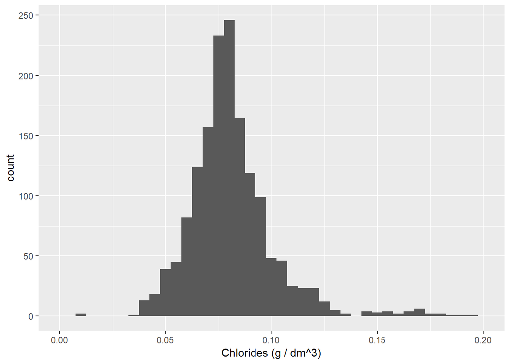

Most chloride values range between 0.05 and 0.10 , the outliers reached the point of 0.6 and the data seemed normally distributed when the data was limited to less than 0.2

### 1.7 Free Sulfur Dioxide

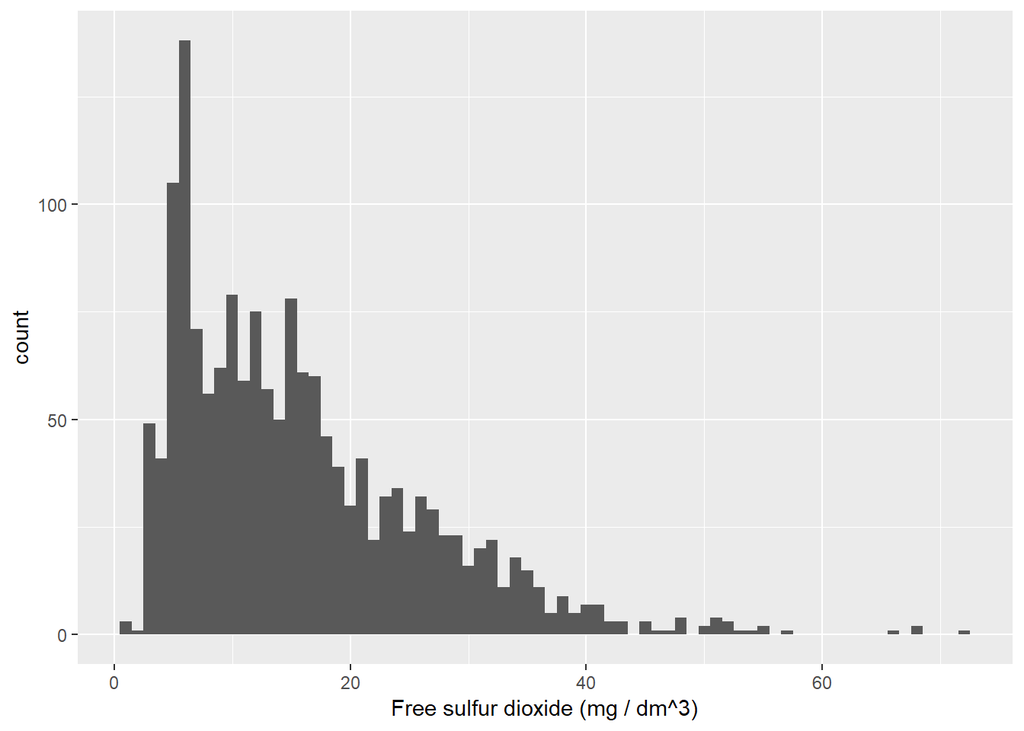

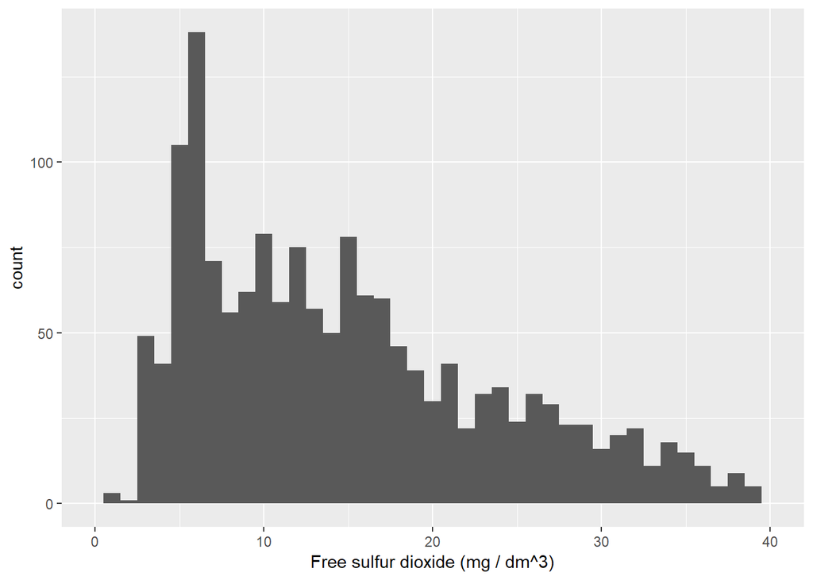

The distribution is strongly skewed to the right even after limiting the data to remove outliers.

### 1.8 Total sulfur dioxide

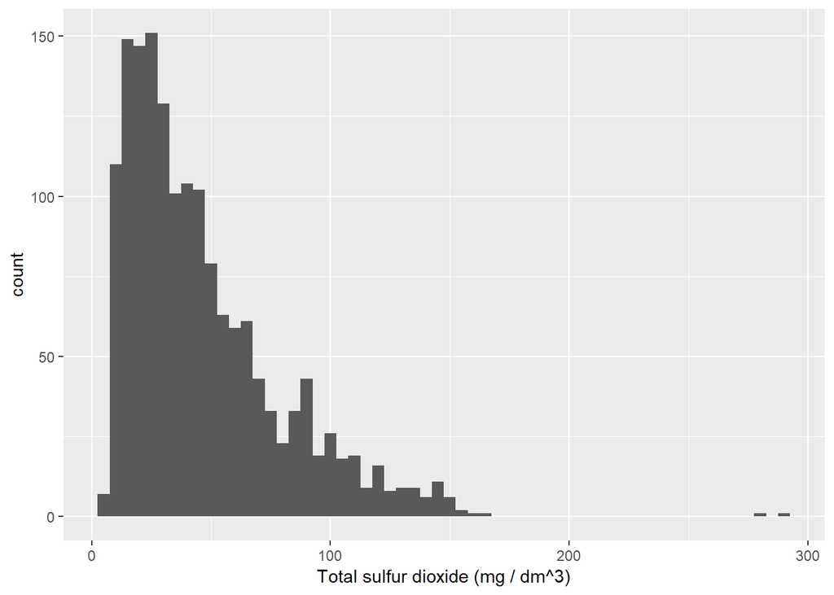

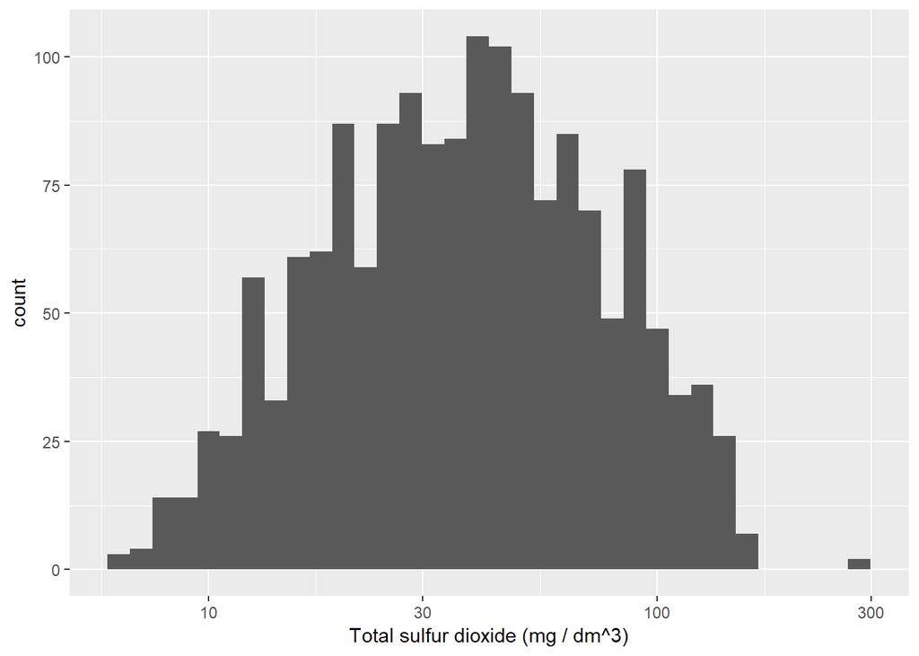

### 1.9 Density

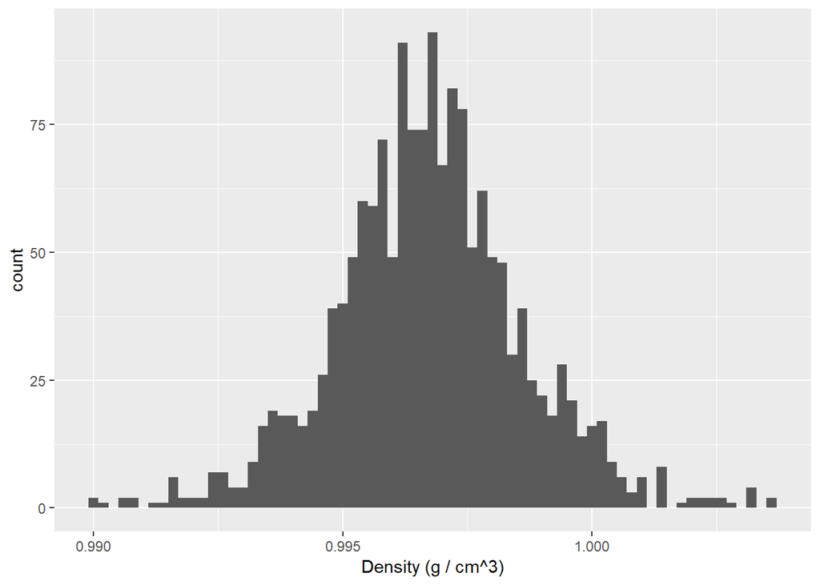

Density values vary between 0.99 and 1. The distribution is normally distributed.

### 1.10 PH

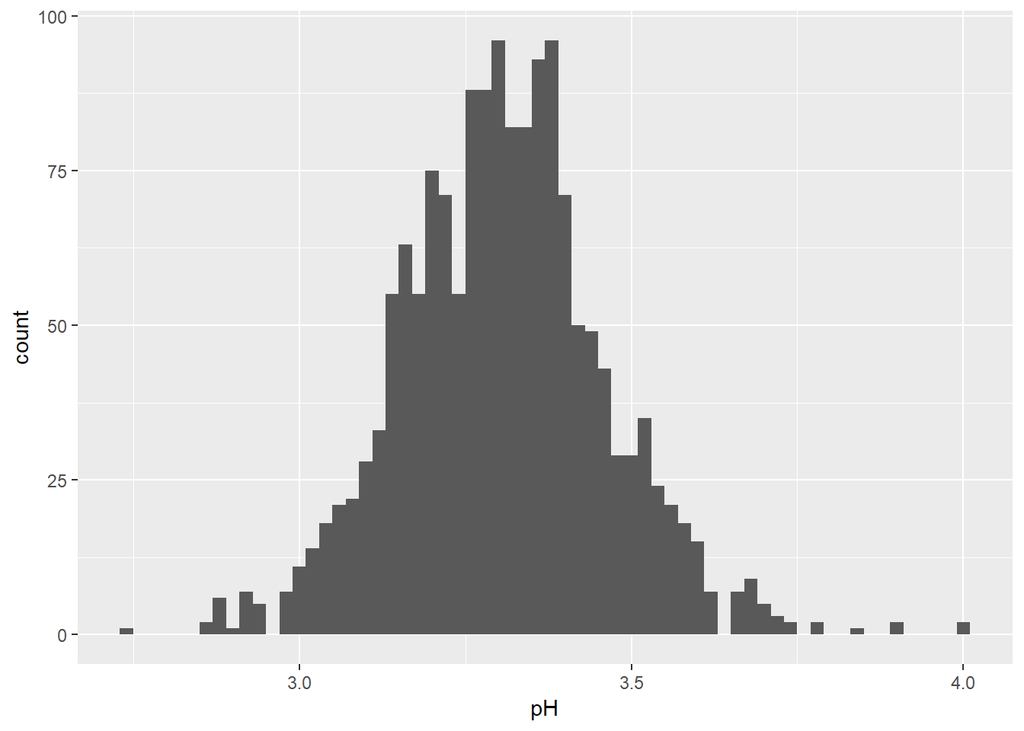

Most pH values are between 3 and 3.5 and thy are symmetrically distributed around 3.3.

### 1.11 Sulphates

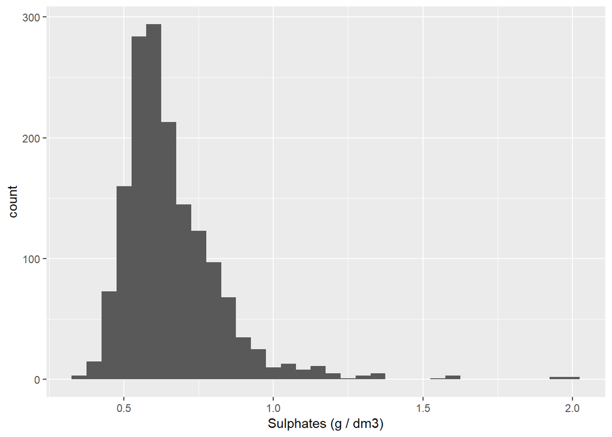

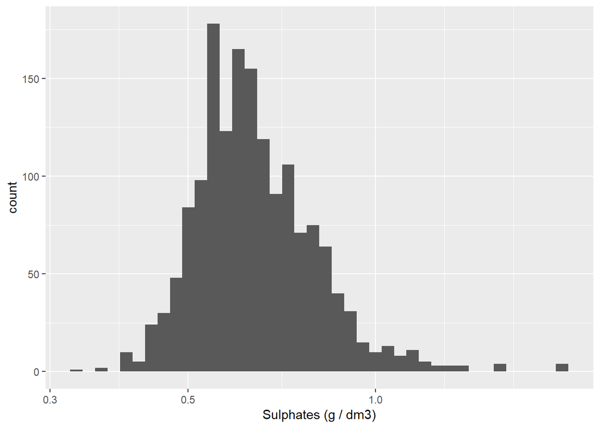

### 1.12 Alcohol

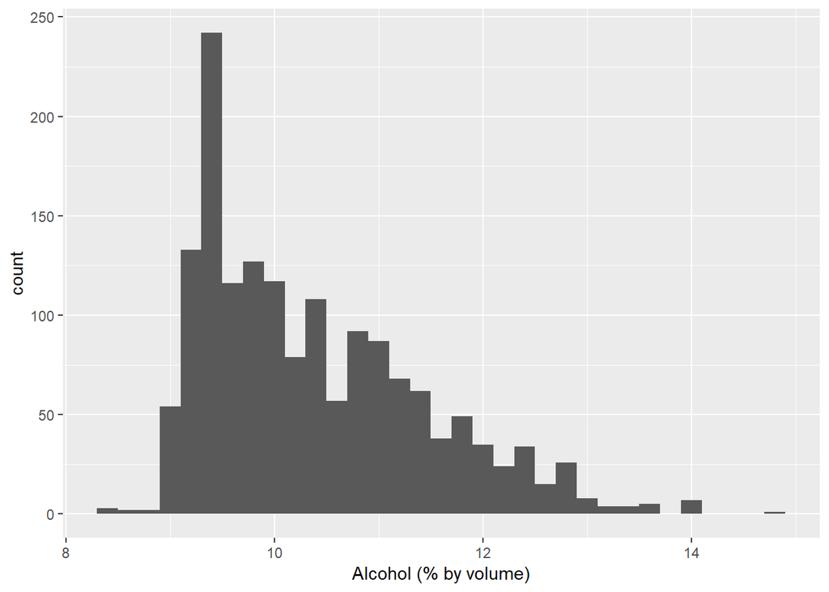

Most alcohol values are in between 8.5 and 14 and the values are positively skewed.

[output not shown]

# Univariate Analysis

### What is the structure of your dataset?

There are 1599 observations of red wine that are analysed based on 11 numeric chemical attributes(fixed acidity, volatile acidity, pH …etc.) and there is one attribute(quality) that is based on sensory data.

The average alcohol value is 10.42, and the average pH is 3.311. Most wines have quality of 5 or 6.

### What is/are the main feature(s) of interest in your dataset?

I think this would be the quality, and it’s important to find out which attributes relate to high quality wine.

### What other features in the dataset do you think will help support your into your feature(s) of interest?

all other 11 attributes other than quality.

### Did you create any new variables from existing variables in the dataset?

No.

### Of the features you investigated, were there any unusual distributions? Did you perform any operations on the data to tidy, adjust, or change the form of the data? If so, why did you do this?

Some attributes had outliers and were long tailed such as citric acid and fixed acidity and other attributes shown above. I used the scale x log10 to make them more normally distributed but they need further investigation.

# Bivariate Plots Section

### 2.1 Quality vs fixed acidity

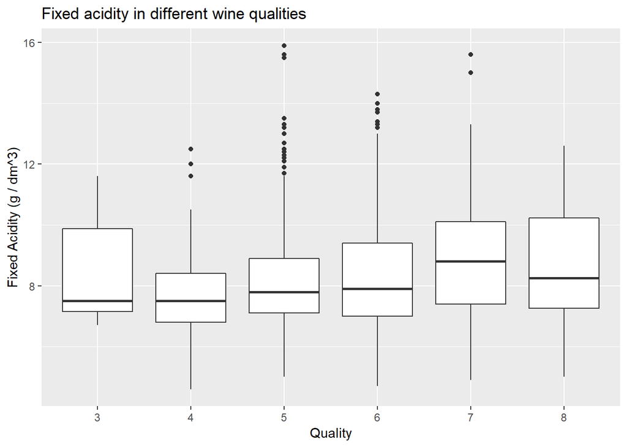

There is no clear relation between quality and fixed acidity

### 2.2 Quality and volatile acidity

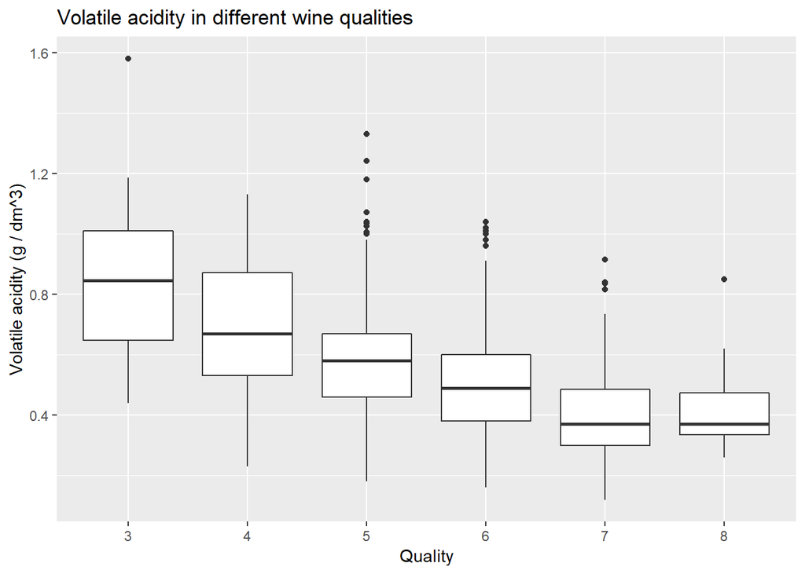

As seen from this plot wine of higher quality have lower values of volatile acidity.

### 2.3 Quality vs citric acidity

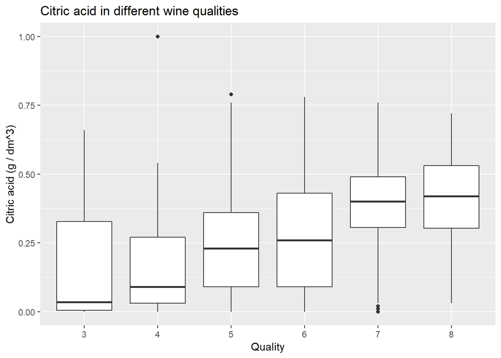

Wine of higher quality has higher citric acid values.

### 2.4 Quality vs residual sugar

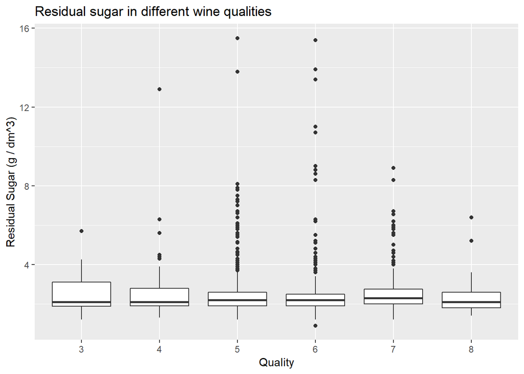

No clear relation between quality and residual sugar level.

### 2.5 Quality vs chlorides

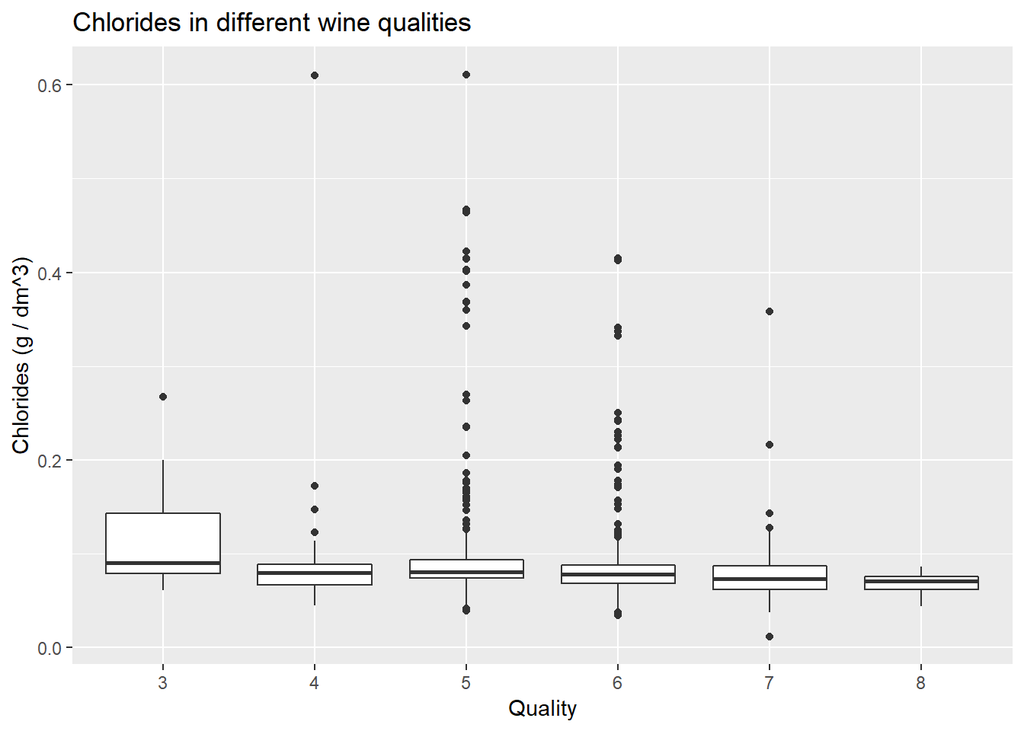

Needs some zoom in.

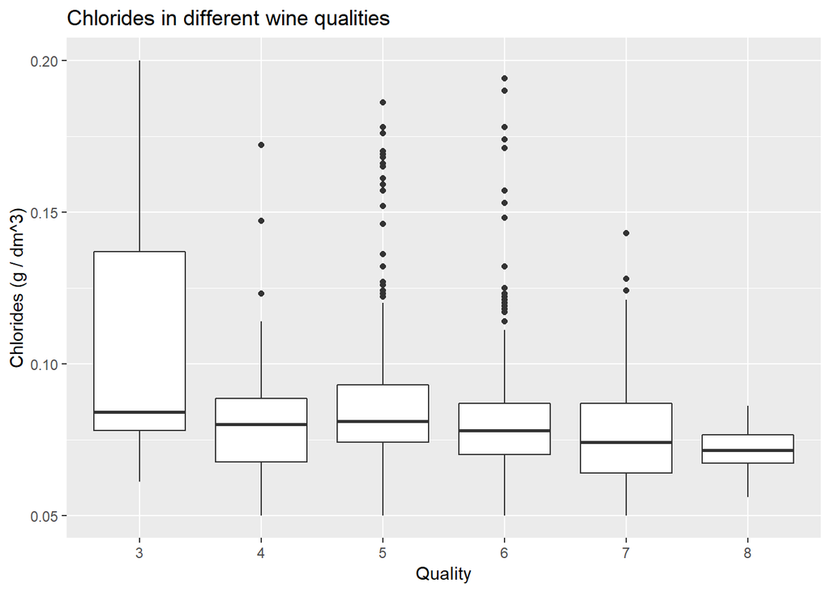

Wines of higher quality has lower chlorides levels.

### 2.6 Quality vs Free sulfur dioxide

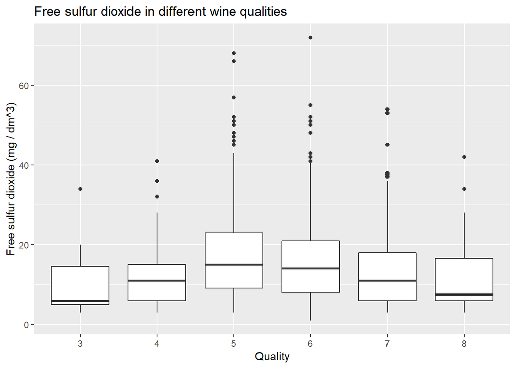

Nothing significant here.

### 2.7 Quality vs Total sulfur dioxide

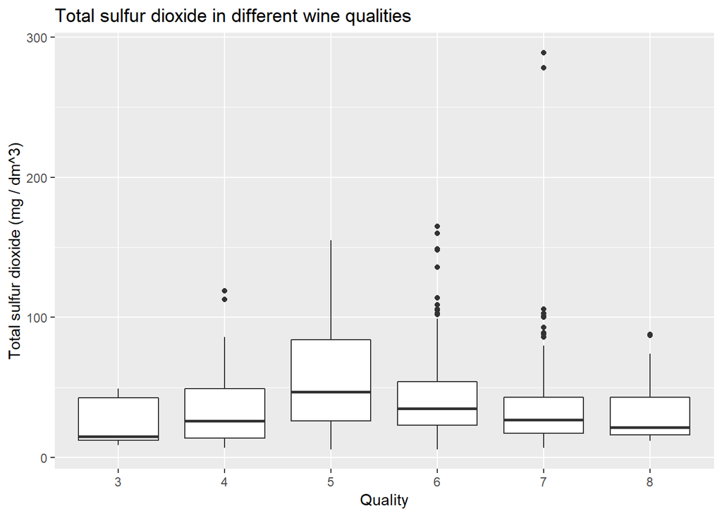

Nothing significant here either.

### 2.8 Quality vs Density

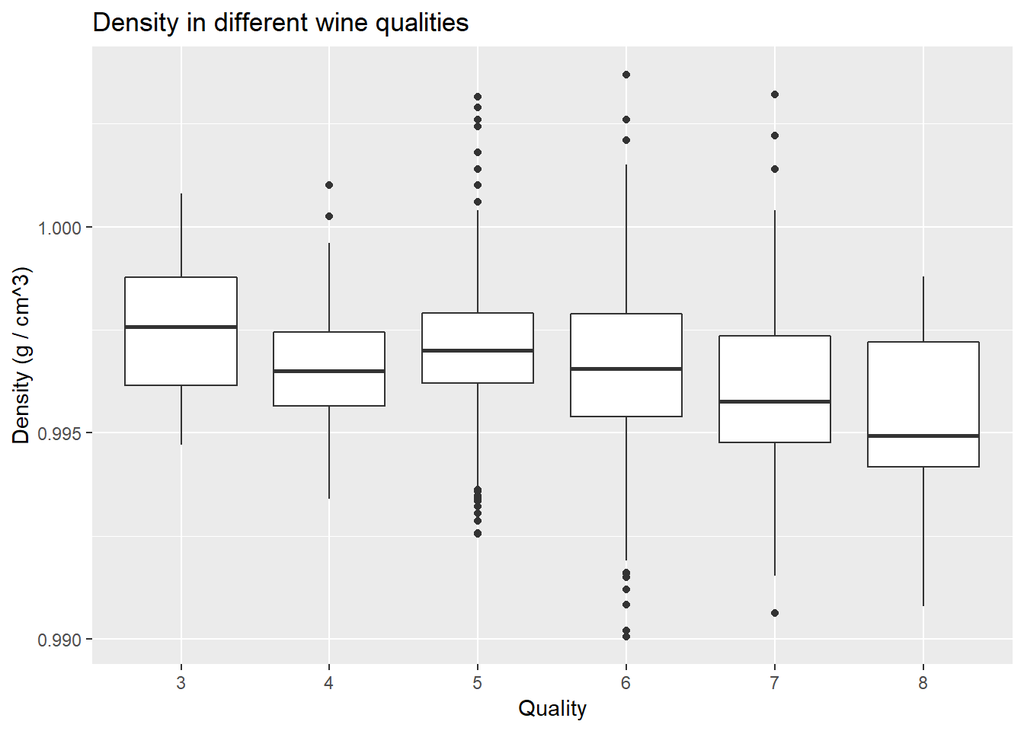

Wine of higher quality has lower density.

### 2.9 Quality vs pH

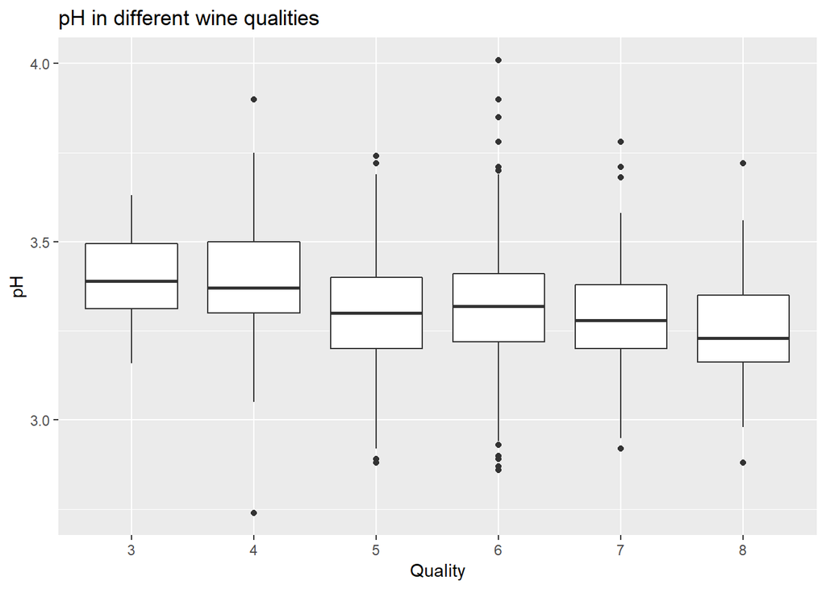

Wine of higher quality has lower pH levels.

### 2.10 Quality vs sulphates

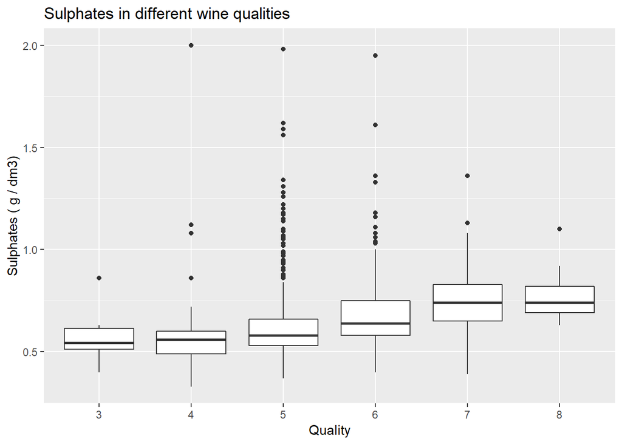

Wine of higher quality has higher sulphate levels.

### 2.11 Quality vs alcohol

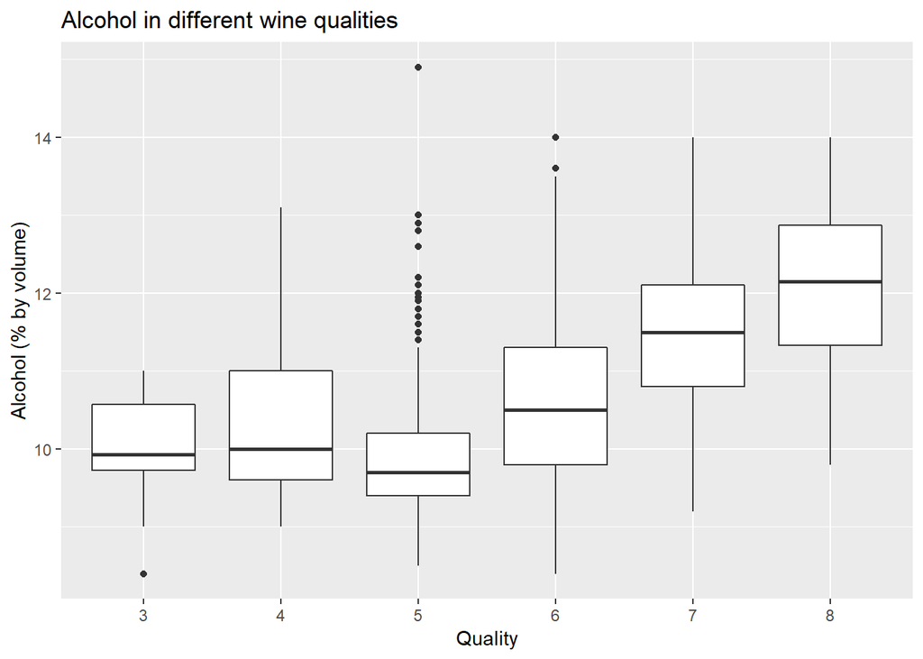

Wine of higher quality has higher levels of alcohol.

Now lets see do further research

### 3.1 Correlation matrix

[output not shown]

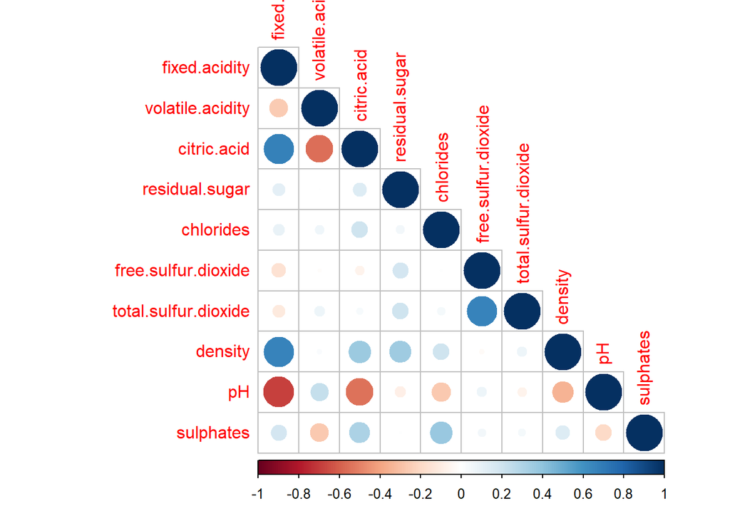

As seen we need to do further research on the following couples: - fixed acidity and citric acid - fixed acidity and density - pH and fixed acidity - Volatile acidity and citric acid - free sulfur dioxide and total sulfur dioxide - Density vs residual sugar